# ELECTRIC HOUSEHOLD POWER CONSUMPTION

[figure not shown]

# *Этот датасет содержит данные о потреблении электроэнергии в одном доме, Sceaux (Франция) в период с декабря 2006 по ноябрь 2010 года. Используется для предсказания индивидуального потребления электроэнергии в домохозяйствах.*

## `Источник:` UCI Machine Learning Repository

## `Период наблюдений:` 4 года. 16.12.2006 — 26.11.2010

## `Частота измерений:` 1 минута

## `Количество наблюдений:` ~2 075 259

## `Количество признаков:` 9

## Структура датасета

[output not shown]

## Целевая переменная

|`Global_active_power`|Общая активная мощность (основной показатель).|кВт

# В данной работе будет ипользоваться классическая задача

# Предсказание общей активной мощности.

## `Global_active_power`

### Основная модель, масштаб - 1 час.

### Доп. модель, масштаб - 1 день.

# Import Library

```python
import tensorflow as tf

def get_best_device():
    # Проверяем, доступен ли GPU
    if tf.config.list_physical_devices('GPU'):
        return '/GPU:0'
    else:
        return '/CPU:0'

# Используем результат функции
device = get_best_device()
print(f"Работаем на: {device}")

with tf.device(device):
    pass
```

```
Работаем на: /GPU:0
```

```python
# 1. Проверяем GPU от AMD
print("Устройства:", tf.config.list_physical_devices())
if any("GPU" in str(d) for d in tf.config.list_physical_devices()):
    print("✅ AMD GPU подключен через DirectML!")
```

```
Устройства: [PhysicalDevice(name='/physical_device:CPU:0', device_type='CPU'), PhysicalDevice(name='/physical_device:GPU:0', device_type='GPU')]
✅ AMD GPU подключен через DirectML!
```

```python
import sys
import numpy as np
from scipy.stats import randint
import pandas as pd
import matplotlib.pyplot as plt
import seaborn as sns
from sklearn.preprocessing import StandardScaler, MinMaxScaler
from sklearn.metrics import mean_squared_error, r2_score

from tensorflow import keras
from tensorflow.keras.layers import Dense, LSTM, Conv1D, MaxPooling1D, Dropout, Input
from tensorflow.keras.models import Sequential
from tensorflow.keras.utils import to_categorical
from tensorflow.keras.optimizers import SGD
from tensorflow.keras.callbacks import EarlyStopping
from tensorflow.keras import utils
```

```python
data = pd.read_csv(
    './household_power_consumption.txt.gz',
    sep=';',
    na_values=['?', 'nan'],
    compression='gzip',
    low_memory=False
)

data['dt'] = pd.to_datetime(
    data['Date'] + ' ' + data['Time'],
    dayfirst=True,
    errors='coerce'
)

data = data.set_index('dt').drop(columns=['Date','Time'])

for col in data.columns:
    data[col] = pd.to_numeric(data[col], errors='coerce')
```

```python
display(data.head())
print('Shape', data.shape)
```

| dt | Global_active_power | Global_reactive_power | Voltage | Global_intensity | Sub_metering_1 | Sub_metering_2 | Sub_metering_3 |
| --- | --- | --- | --- | --- | --- | --- | --- |
| 2006-12-16 17:24:00 | 4.216 | 0.418 | 234.84 | 18.4 | 0.0 | 1.0 | 17.0 |
| 2006-12-16 17:25:00 | 5.360 | 0.436 | 233.63 | 23.0 | 0.0 | 1.0 | 16.0 |
| 2006-12-16 17:26:00 | 5.374 | 0.498 | 233.29 | 23.0 | 0.0 | 2.0 | 17.0 |
| 2006-12-16 17:27:00 | 5.388 | 0.502 | 233.74 | 23.0 | 0.0 | 1.0 | 17.0 |
| 2006-12-16 17:28:00 | 3.666 | 0.528 | 235.68 | 15.8 | 0.0 | 1.0 | 17.0 |

```
Shape (2075259, 7)
```

```python
data.info()
```

```
<class 'pandas.core.frame.DataFrame'>
DatetimeIndex: 2075259 entries, 2006-12-16 17:24:00 to 2010-11-26 21:02:00
Data columns (total 7 columns):
 #   Column                 Dtype
---  ------                 -----
 0   Global_active_power    float64
 1   Global_reactive_power  float64
 2   Voltage                float64
 3   Global_intensity       float64
 4   Sub_metering_1         float64
 5   Sub_metering_2         float64
 6   Sub_metering_3         float64
dtypes: float64(7)
memory usage: 126.7 MB
```

```python
data.describe()
```

|  | Global_active_power | Global_reactive_power | Voltage | Global_intensity | Sub_metering_1 | Sub_metering_2 | Sub_metering_3 |
| --- | --- | --- | --- | --- | --- | --- | --- |
| count | 2.049280e+06 | 2.049280e+06 | 2.049280e+06 | 2.049280e+06 | 2.049280e+06 | 2.049280e+06 | 2.049280e+06 |
| mean | 1.091615e+00 | 1.237145e-01 | 2.408399e+02 | 4.627759e+00 | 1.121923e+00 | 1.298520e+00 | 6.458447e+00 |
| std | 1.057294e+00 | 1.127220e-01 | 3.239987e+00 | 4.444396e+00 | 6.153031e+00 | 5.822026e+00 | 8.437154e+00 |
| min | 7.600000e-02 | 0.000000e+00 | 2.232000e+02 | 2.000000e-01 | 0.000000e+00 | 0.000000e+00 | 0.000000e+00 |
| 25% | 3.080000e-01 | 4.800000e-02 | 2.389900e+02 | 1.400000e+00 | 0.000000e+00 | 0.000000e+00 | 0.000000e+00 |
| 50% | 6.020000e-01 | 1.000000e-01 | 2.410100e+02 | 2.600000e+00 | 0.000000e+00 | 0.000000e+00 | 1.000000e+00 |
| 75% | 1.528000e+00 | 1.940000e-01 | 2.428900e+02 | 6.400000e+00 | 0.000000e+00 | 1.000000e+00 | 1.700000e+01 |
| max | 1.112200e+01 | 1.390000e+00 | 2.541500e+02 | 4.840000e+01 | 8.800000e+01 | 8.000000e+01 | 3.100000e+01 |

# First-look analysis

## Missing Values

```python
missing_data = (pd.concat([data.isna().sum(), data.isna().mean() * 100],
                          keys = ['count','%'],
                          axis = 1)).sort_values(ascending=False, by='count')

missing_data = missing_data[missing_data['count'] > 0]
missing_data
```

|  | count | % |
| --- | --- | --- |
| Global_active_power | 25979 | 1.251844 |
| Global_reactive_power | 25979 | 1.251844 |
| Voltage | 25979 | 1.251844 |
| Global_intensity | 25979 | 1.251844 |
| Sub_metering_1 | 25979 | 1.251844 |
| Sub_metering_2 | 25979 | 1.251844 |
| Sub_metering_3 | 25979 | 1.251844 |

```python
def missing_period_plot(df, resample='Y', figsize=(15,3)):
    df.isna().resample(resample).sum().plot(figsize=figsize)

    plt.legend(fontsize='small')
    plt.title(f"Missing values per {resample}")
    plt.show()
```

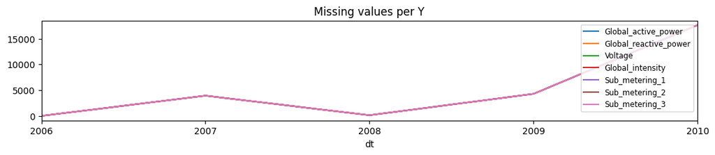

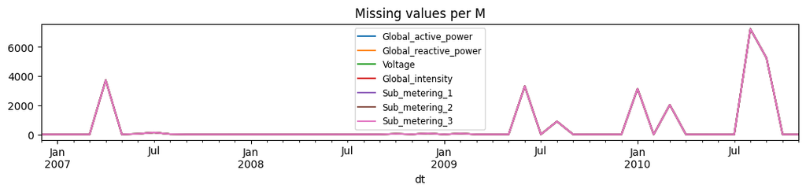

```python
for period in ['Y', 'M']:
    missing_period_plot(data, period, figsize=(13, 2))
```

## Из графика видно что пропуски одинаковы по всем признакам. Что говорит о единой природе их возникновения.

```python
yearly_missing = (
    data.isna().any(axis=1).groupby(data.index.year).mean().mul(100).reset_index()
)

yearly_missing.columns = ['Year', 'Missing %']
yearly_missing
```

|  | Year | Missing % |
| --- | --- | --- |
| 0 | 2006 | 0.018185 |
| 1 | 2007 | 0.747907 |
| 2 | 2008 | 0.025615 |
| 3 | 2009 | 0.814307 |
| 4 | 2010 | 3.711189 |

```python
def missing_plot_calendar(df, period, figsize=(10, 4)):
    idx = getattr(df.Global_active_power.index, period)
    missing = df.Global_active_power.isna().groupby(idx).sum()

    ax = missing.plot(kind='bar', figsize=figsize, color='DarkCyan')

    for p in ax.patches:
        height = p.get_height()
        ax.annotate(
            f'{int(height)}',
            (p.get_x() + p.get_width() / 2, height),
            ha='center',
            va='bottom',
            fontsize=10,
            rotation=0
        )

    plt.title(f'Missing values sum per {period}')
    plt.tight_layout()
    plt.show()
```

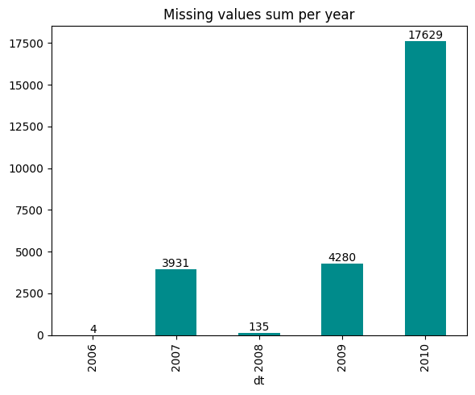

```python
missing_plot_calendar(data, 'year', (6, 5))
```

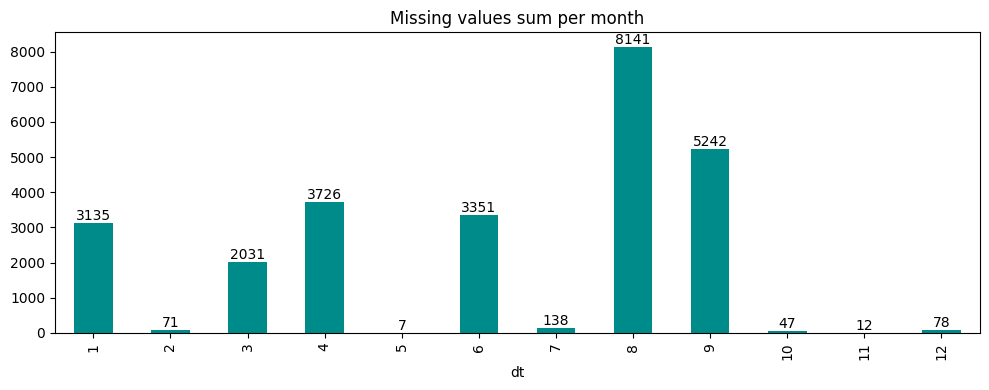

```python
missing_plot_calendar(data, 'month', (10, 4))
```

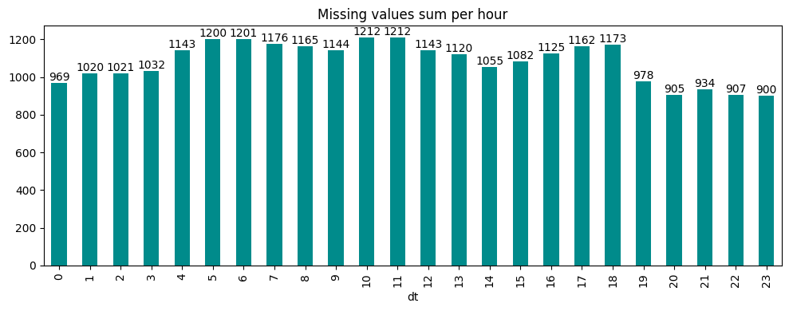

```python
missing_plot_calendar(data, 'hour')
```

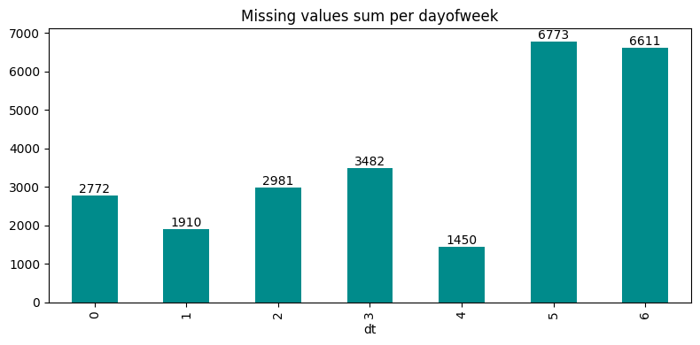

```python
missing_plot_calendar(data, 'dayofweek', (8, 4))
```

```python
missing_mask = data.isna().any(axis=1)
gap_group = missing_mask.ne(missing_mask.shift()).cumsum()

gap_intervals = (
    data[missing_mask]
    .groupby(gap_group[missing_mask])
    .apply(lambda x, **kwargs: (x.index.min(), x.index.max()))
)

gap_df = gap_intervals.to_frame(name='interval')

gap_df['duration_min'] = gap_df['interval'].apply(
    lambda x: (x[1] - x[0]).total_seconds() / 60
)

gaps_over_1min = gap_df[gap_df['duration_min'] > 59].copy()

gaps_over_1min['missing_interval'] = gaps_over_1min['interval'].apply(
    lambda x: f"{x[0].strftime('%Y-%m-%d')} → {x[1].strftime('%Y-%m-%d')}"
)

daily_gaps = gaps_over_1min.groupby('missing_interval')['duration_min'].sum()
```

```python
gaps_over_1min
```

|  | interval | duration_min | missing_interval |
| --- | --- | --- | --- |
| 14 | (2007-04-28 00:21:00, 2007-04-30 14:23:00) | 3722.0 | 2007-04-28 → 2007-04-30 |
| 32 | (2007-07-15 16:49:00, 2007-07-15 18:11:00) | 82.0 | 2007-07-15 → 2007-07-15 |
| 78 | (2008-12-10 10:48:00, 2008-12-10 11:57:00) | 69.0 | 2008-12-10 → 2008-12-10 |
| 100 | (2009-06-13 00:30:00, 2009-06-15 07:34:00) | 3304.0 | 2009-06-13 → 2009-06-15 |
| 104 | (2009-08-13 05:00:00, 2009-08-13 19:50:00) | 890.0 | 2009-08-13 → 2009-08-13 |
| 118 | (2010-01-12 14:53:00, 2010-01-14 19:01:00) | 3128.0 | 2010-01-12 → 2010-01-14 |
| 126 | (2010-03-20 03:52:00, 2010-03-21 13:38:00) | 2026.0 | 2010-03-20 → 2010-03-21 |
| 138 | (2010-08-17 21:02:00, 2010-08-22 21:27:00) | 7225.0 | 2010-08-17 → 2010-08-22 |
| 140 | (2010-09-25 03:56:00, 2010-09-28 19:12:00) | 5236.0 | 2010-09-25 → 2010-09-28 |

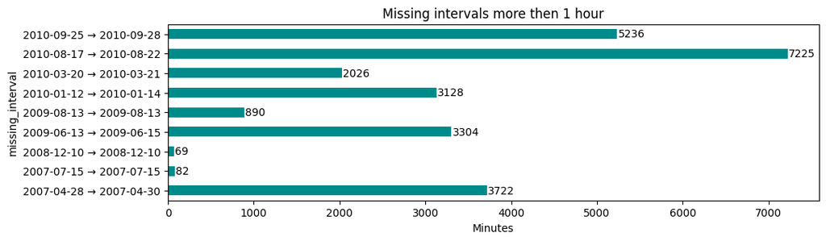

```python
ax = daily_gaps.plot(kind='barh', figsize=(11, 3), color='darkcyan')
plt.title("Missing intervals more then 1 hour")
plt.xlabel("Minutes")
[ax.text(v + 10, i, f'{v:.0f}', va='center') for i, v in enumerate(daily_gaps)];
```

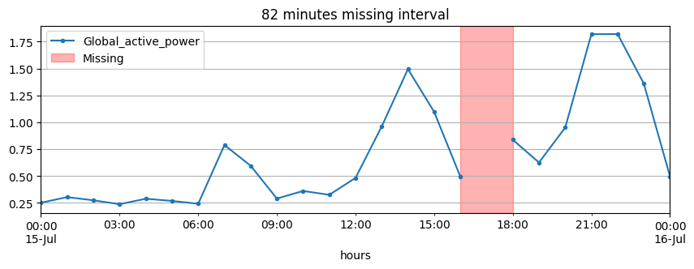

```python
ax = data.resample('h').mean().loc['2007-07-15 00:00:00':'2007-07-16 00:00:00', 'Global_active_power'] \
                     .plot(marker=".", figsize=[10, 3], legend=None)

ax.axvspan('2007-07-15 16:49:00', '2007-07-15 18:11:00',color='red', alpha=0.3, label='Missing')

plt.title("82 minutes missing interval")
plt.xlabel("hours")
ax.legend()
ax.grid(True)
```

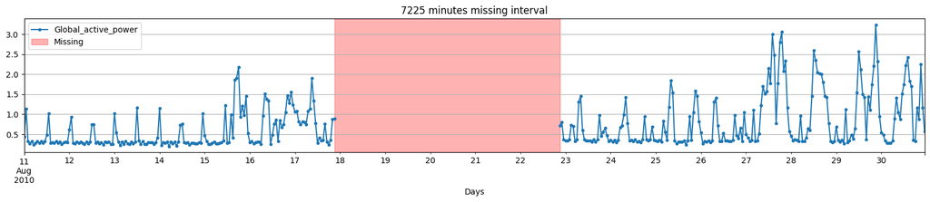

```python
ax = data.resample('h').mean().loc['2010-08-11':'2010-08-30', 'Global_active_power'] \
                     .plot(marker=".", figsize=[20, 3], legend=None)

ax.axvspan('2010-08-17 21:02:00', '2010-08-22 21:27:00', color='r', alpha=0.3, label='Missing')
plt.title("7225 minutes missing interval")
plt.xlabel("Days")
ax.legend()
ax.grid(True)
```

```python
data_impute_linear = data.resample('h').mean().interpolate('linear')
```

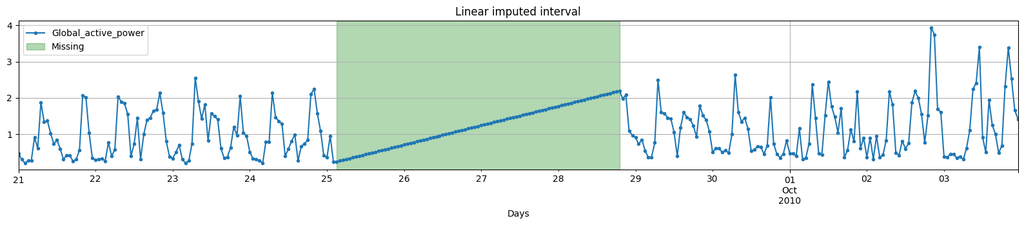

```python
ax = data_impute_linear.loc['2010-09-21':'2010-10-03', 'Global_active_power'] \
                     .plot(marker=".", figsize=[20, 3], legend=None)

ax.axvspan('2010-09-25 03:56:00', '2010-09-28 19:12:00', color='g', alpha=0.3, label='Missing')
plt.title("Linear imputed interval")
plt.xlabel("Days")
ax.legend()
ax.grid(True)
```

```python
data_impute_spline = data.resample('h').mean().interpolate('spline', order=3)
```

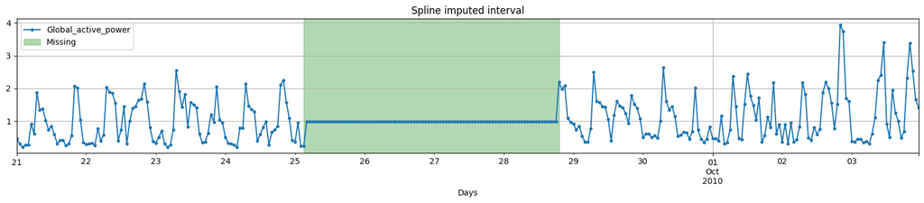

```python
ax = data_impute_spline.loc['2010-09-21':'2010-10-03', 'Global_active_power'] \
                     .plot(marker=".", figsize=[20, 3], legend=None)

ax.axvspan('2010-09-25 03:56:00', '2010-09-28 19:12:00', color='g', alpha=0.3, label='Missing')
plt.title("Spline imputed interval")
plt.xlabel("Days")
ax.legend()
ax.grid(True)
```

```python
data_resampled_H = data.resample('h').agg({
    'Global_active_power': 'mean',
    'Global_reactive_power': 'mean',
    'Voltage': 'mean',
    'Global_intensity': 'mean',
    'Sub_metering_1': 'sum',
    'Sub_metering_2': 'sum',
    'Sub_metering_3': 'sum'
})
data_resampled_H.isna().sum()
```

```
Global_active_power      421
Global_reactive_power    421
Voltage                  421
Global_intensity         421
Sub_metering_1             0
Sub_metering_2             0
Sub_metering_3             0
dtype: int64
```

```python
mask_empty_hours = data_resampled_H['Global_active_power'].isna()
cols_sum = ['Sub_metering_1', 'Sub_metering_2', 'Sub_metering_3']

data_resampled_H.loc[mask_empty_hours, cols_sum] = \
    data_resampled_H.loc[mask_empty_hours, cols_sum].replace(0, np.nan)
data_resampled_H.isna().sum()
```

```
Global_active_power      421
Global_reactive_power    421
Voltage                  421
Global_intensity         421
Sub_metering_1           421
Sub_metering_2           421
Sub_metering_3           421
dtype: int64
```

```python
from statsmodels.tsa.seasonal import MSTL

results = {}
seasonal_components = pd.DataFrame(index=data_resampled_H.index)

# 1. MSTL для каждой колонки
for col in data_resampled_H.columns:
    s = data_resampled_H[col].interpolate()

    # Мультисезонная декомпозиция: сутки + неделя
    m = MSTL(s, periods=[24, 24*7])
    res = m.fit()

    results[col] = res

    # Суммируем все сезонности (MSTL возвращает матрицу seasonal)
    seasonal_components[col] = res.seasonal.sum(axis=1)

# 2. Десезонализация
df_deseasonalised = data_resampled_H - seasonal_components

# 3. Интерполяция пропусков на десезонализированном ряду
df_deseasonalised_imputed = df_deseasonalised.interpolate(method="linear")
```

```python
# 4. Возвращаем сезонность
data_imputed_MSTL = df_deseasonalised_imputed + seasonal_components
```

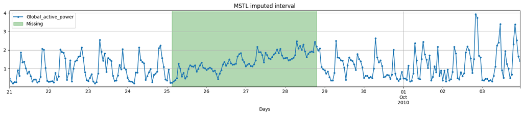

```python
ax = data_imputed_MSTL.loc['2010-09-21':'2010-10-03', 'Global_active_power'] \
                     .plot(marker=".", figsize=[20, 3], legend=None)

ax.axvspan('2010-09-25 03:56:00', '2010-09-28 19:12:00', color='g', alpha=0.3, label='Missing')
plt.title("MSTL imputed interval")
plt.xlabel("Days")
ax.legend()
ax.grid(True)
```

Ни одна из этих дат не совпадает с крупными природными катастрофами, зафиксированными в международных базах.

Это не исключает локальные события: отключения электроэнергии, перегрузки, аварии на подстанциях, плановые работы или сбои связи.

Особенно длительные пропуски могут указывать на аварии в инфраструктуре, особенно в августе, когда во Франции часто проводятся технические работы и отпускной режим.

Повторяющиеся значения в строках — это просто разные признаки, но пропуски одинаковы для всех.

Анализ паттерна пропусков по годам выглядит как:

- постепенная деградация оборудования,
- периодические ремонты,
- окончательный выход из строя.
- пропуски в летние месяцы возможно связанны с отпуском.

# Итог:

## Деградация оборудования и нерегулярная запись в последние месяцы сбора данных.

## Пропуски — это не природные катаклизмы, а особенности работы измерительного оборудования.

Это подтверждается:

- структурой пропусков,
- документацией UCI,
- анализами других исследователей,
- отсутствием внешних катастроф в эти даты.

# Практическая рекомендация:

### Не смотря на малый процент 1.25% на общем датасете, пропуски значительно отличаются по годам.

### Особенно 2010 год 3.7%.

### Исключени пропусков даст не верный результат.

### Пропуски обязательно восстановить.

### Используем метод замены интерполяции с сохранением сезонности и тренда (MSTL).

```python
%%time
from sklearn.ensemble import RandomForestRegressor
from sklearn.metrics import mean_absolute_error

def model_rf(df):
# 3. Features and target
    X = df[['Voltage', 'Global_intensity', 'Sub_metering_1',
            'Sub_metering_2', 'Sub_metering_3']]
    y = df['Global_active_power']

    # 4. Correct train/test split
    train = df[df.index.year <= 2008]
    test_good = df[df.index.year == 2009]
    test_bad = df[df.index.year == 2010]

    # 5. Fit model
    model = RandomForestRegressor()
    model.fit(train[X.columns], train[y.name])

    # 6. Predict
    pred_good = model.predict(test_good[X.columns])
    pred_bad = model.predict(test_bad[X.columns])

    # 7. Evaluate
    print("MAE на нормальных данных (2009):",
          mean_absolute_error(test_good[y.name], pred_good))

    print("MAE на деградированных данных (2010):",
          mean_absolute_error(test_bad[y.name], pred_bad))
```

```
CPU times: total: 156 ms
Wall time: 147 ms
```

```python
model_rf(data_impute_linear)
```

```
MAE на нормальных данных (2009): 0.01461435171091018
MAE на деградированных данных (2010): 0.015662529446564936
```

```python
model_rf(data_impute_spline)
```

```
MAE на нормальных данных (2009): 0.016912820865782108
MAE на деградированных данных (2010): 0.10584853979928589
```

```python
model_rf(data_imputed_MSTL)
```

```
MAE на нормальных данных (2009): 0.01462315375843188
MAE на деградированных данных (2010): 0.015903182603227064
```

### Рекомендация: используем метод интерполяции — это способ восстановить пропущенные значения в данных, опираясь на уже существующие точки.

### Умное “дорисовывание” недостающих значений так, чтобы кривая выглядела естественно.

# Корелляционный анализ

```python
def corrMatrix(data, resample_over = ''):
    plt.figure(figsize=(15, 6))
    plt.subplot(1, 2, 1)
    sns.heatmap(data.corr(method="pearson"), annot=True, cmap="RdYlGn", fmt=".2f")
    plt.title("Pearson - " + resample_over)

    plt.subplot(1, 2, 2)
    sns.heatmap(data.corr(method="spearman"), annot=True, cmap="RdYlGn", fmt=".2f")
    plt.title("Spearman - " + resample_over)

    plt.tight_layout()
    plt.show()
```

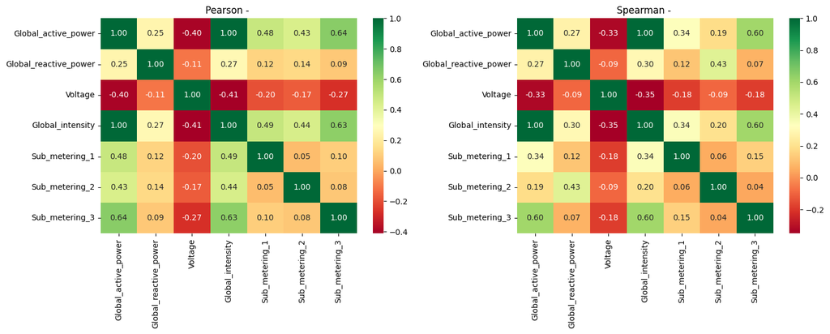

```python
corrMatrix(data)
```

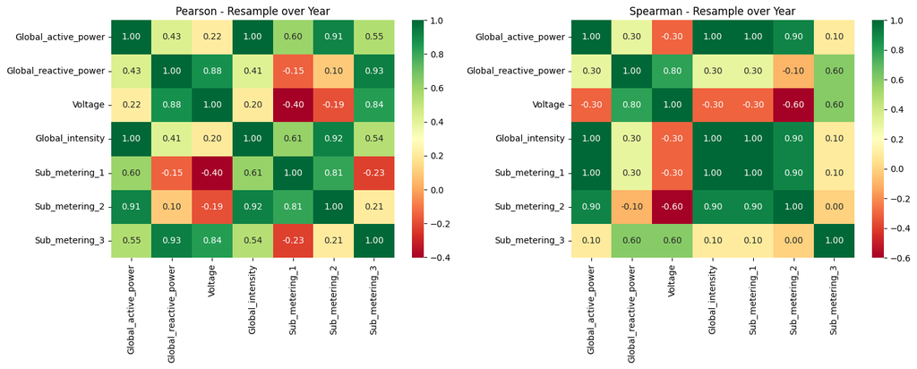

```python
corrMatrix(data.resample('Y').mean(), resample_over='Resample over Year')
```

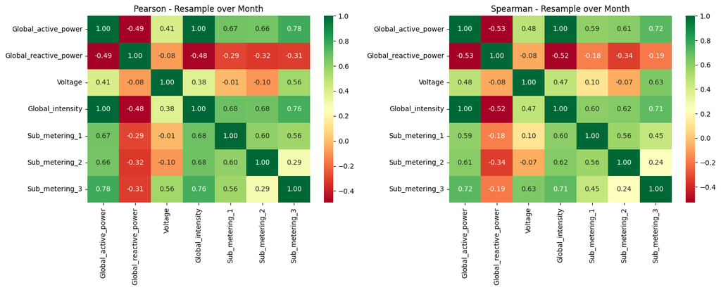

```python
corrMatrix(data.resample('M').mean(), 'Resample over Month')
```

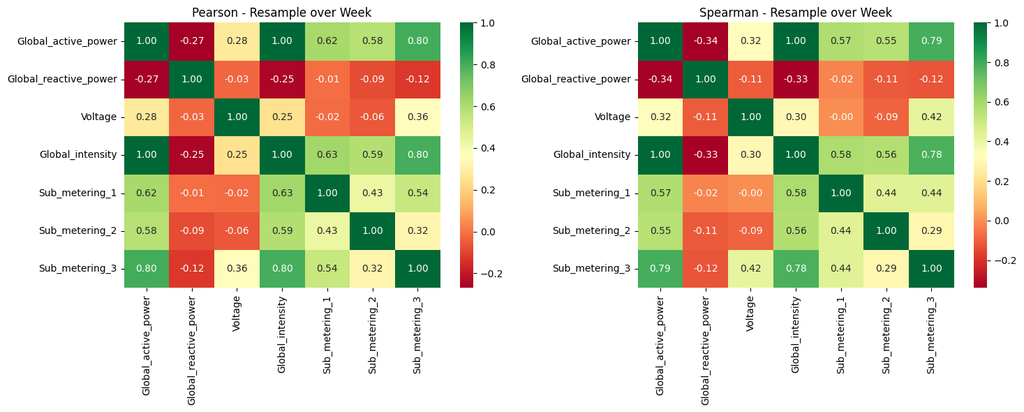

```python
corrMatrix(data.resample('W').mean(), 'Resample over Week')
```

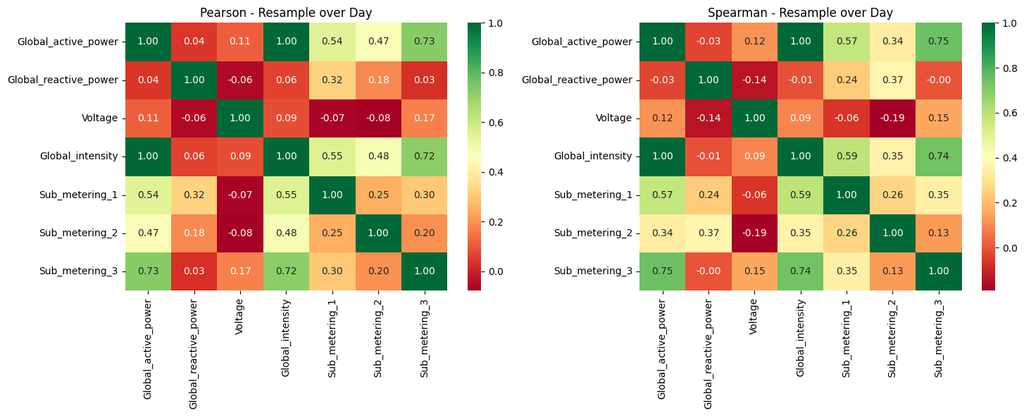

```python
corrMatrix(data.resample('D').mean(), 'Resample over Day')
```

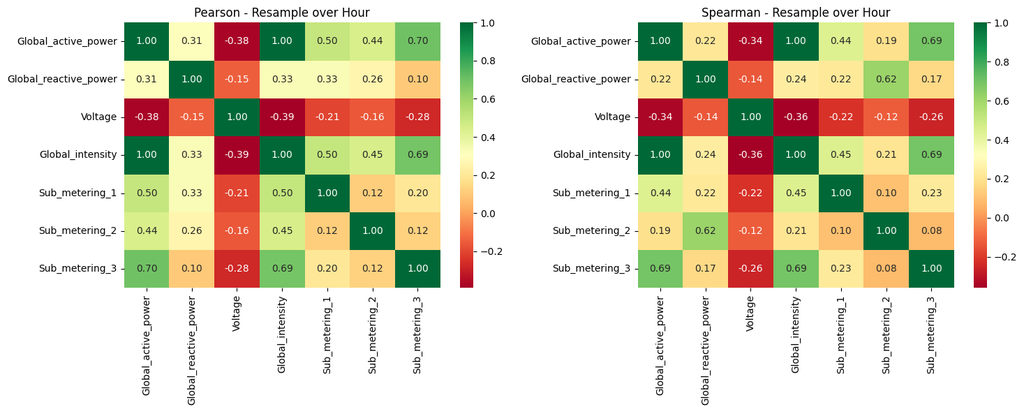

```python
corrMatrix(data.resample('h').mean(), 'Resample over Hour')
```

`Global_intensity` - корреляция ≈ 1.0

- Одна физическая суть. Активная мощность - произведение напряжения и тока.
- В условиях использования RNN(LSTM) высокий уровень корреляции не является дублированием информации.
- Временные патерны изменяются, важна динамика измениний, LSTM использует градиенты во времени.

`Global_reactive_power` - низкая корреляция.

`Voltage` - низкая корреляция.

- дает информацию по качеству сети и состоянию.
- на больших масштабах показывает общий тренд, нагрузки по сезонам.
- на малых масштабах показывает колебания сети, скачки и просадки от перегрузки.
- требует нормализации.
- полезен на малых масштабах.

`Sub_metering_1`

- признак информативна на крупных масштабах, за счет сглаживания показателей.
- на мелких возможен шум, имеет случайный характер.

`Sub_metering_2`

- аналогично Sub_metering_1
- возможно крупные приборы лучше отражают паттерны на протяжении дня и днях недели (выходные, будни).

`Sub_metering_3` - высокие показатели корреляции.

- самый полезный признак из имеющихся, так как в отличии от признаков собратьев класса sub_metering имеет более структурный и постоянный сигнал.

# EDA analysis

```python
def trend_plot(feature, resample_over):
    (data[feature]
        .resample(resample_over)
        .sum()
        .plot(title=f'{feature} resampled over {resample_over} for sum'))

    plt.tight_layout()
    plt.show()

    (data[feature]
        .resample(resample_over)
        .mean()
        .plot(title=f'{feature} resampled over {resample_over} for mean', color='r'))

    plt.tight_layout()
    plt.show()
```

# `Trends over period`

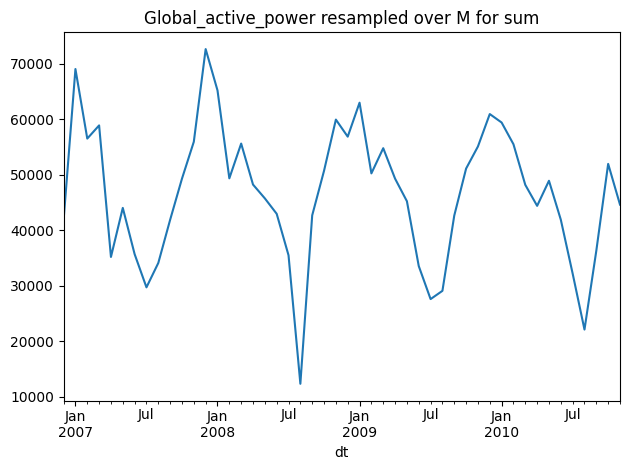

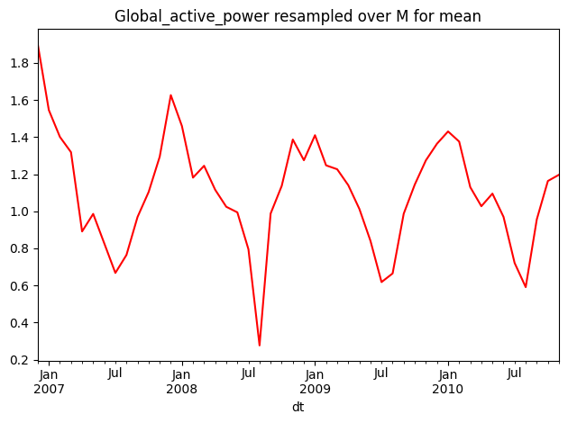

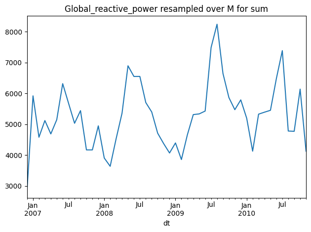

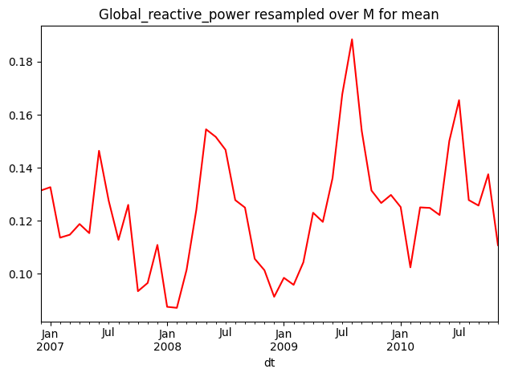

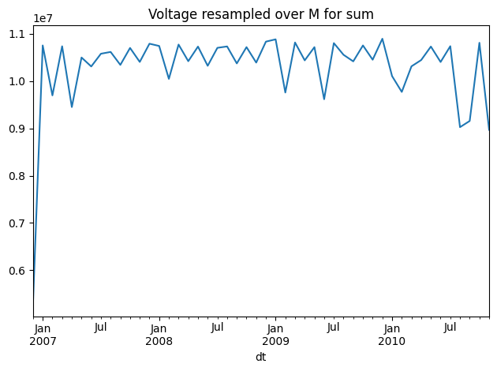

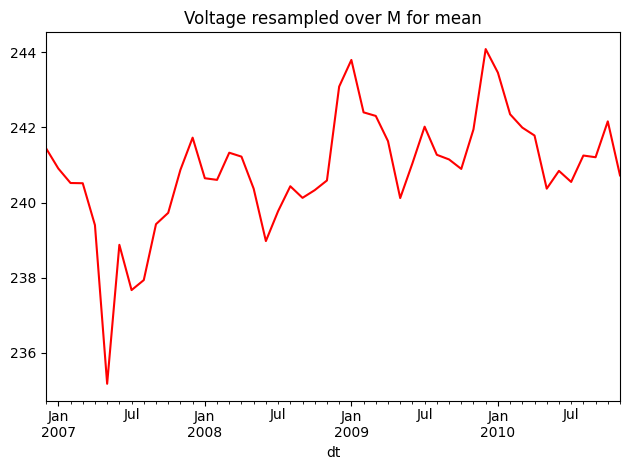

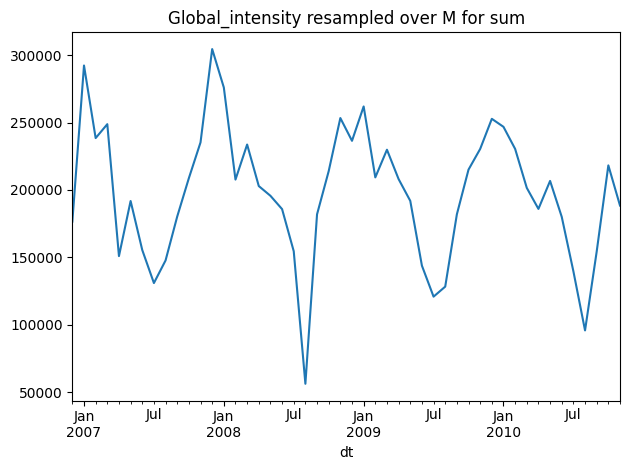

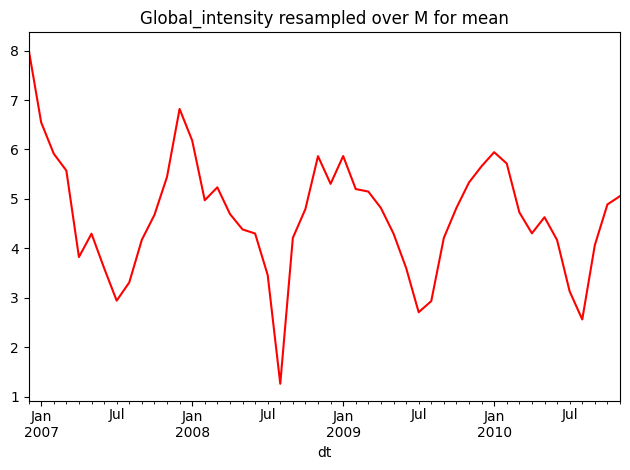

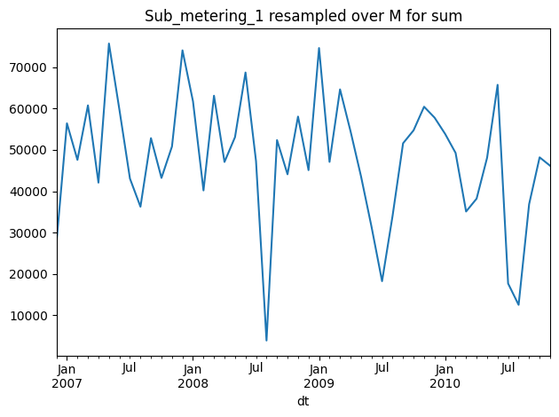

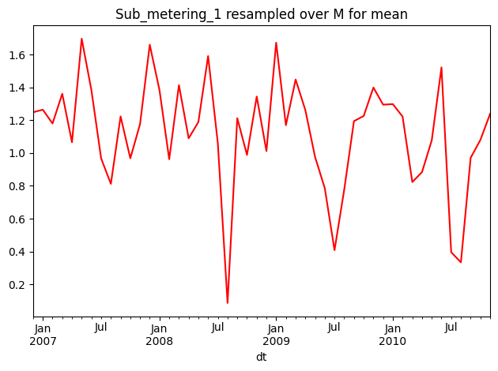

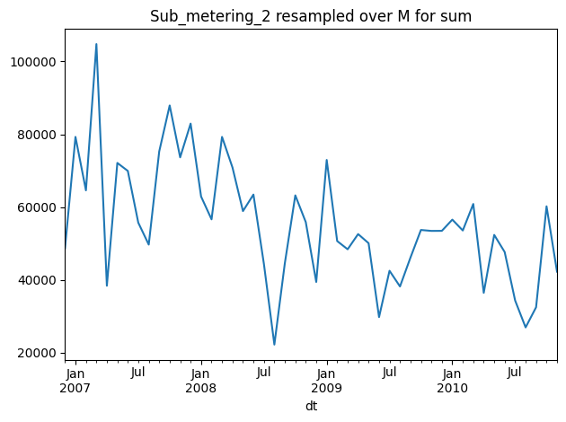

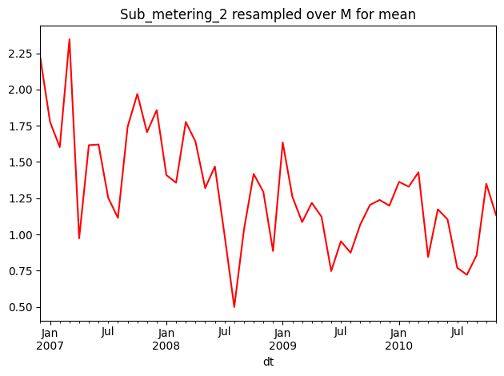

[2 more figures not shown]

```python
for col in data.columns:
    trend_plot(col, 'M')
```